# Report - PCA for PhenotyperPCA Project

Kate Konrad

2026-06-25

# Results

Here, we present the results of for the analysis of the data. This output includes:

- A heatmap of the data values
- Parameter significance plots
- The percent of variation explained by notable PCs
- ANOVA tests for notable PCs
- Tukey pairwise comparison testing for notable PCs
- PC loading plots colored by Variable Type and Covariate Signifiance
- Boxplots of notable PC scores

This analysis is an example used for the template

Variables that are used in the analysis include Sex and Group (with possible values of 0 mg/kg, 0.5 mg/kg, 5 mg/kg) and their interactions.

## Data

This dataset was called ../Data for Practice/15_join01and13L_prenatalCPF.xlsx. First, we looked at a heatmap of the data, followed by removing variables that are highly correlated.

### Excluded variables

There were 25 variables that were intentionally removed from analysis. These were:

```
##  [1] "Mean activity duration - dark (s)"
##  [2] "Mean short arrest duration - dark (s)"
##  [3] "Mean long arrest duration - dark (s)"
##  [4] "Mean short shelter visit duration - dark (s)"
##  [5] "Mean long movement distance - dark (cm)"
##  [6] "Mean short movement distance - dark (cm)"
##  [7] "Mean activity duration - habituation ratio dark (ratio)"
##  [8] "Mean short arrest duration - habituation ratio dark (ratio)"
##  [9] "Mean long arrest duration - habituation ratio dark (ratio)"
## [10] "Mean short shelter visit duration - habituation ratio dark (ratio)"
## [11] "Mean long movement distance - habituation ratio dark (ratio)"
## [12] "Mean short movement distance - habituation ratio dark (ratio)"
## [13] "Mean long shelter visit duration (s)"
## [14] "Mean activity duration - light (s)"
## [15] "Mean short arrest duration - light (s)"
## [16] "Mean long arrest duration - light (s)"
## [17] "Mean short shelter visit duration - light (s)"
## [18] "Mean long movement distance - light (cm)"
## [19] "Mean short movement distance - light (cm)"
## [20] "Mean activity duration - darklight index (index)"
## [21] "Mean short arrest duration - darklight index (index)"
## [22] "Mean long arrest duration - darklight index (index)"
## [23] "Mean short shelter visit duration - darklight index (index)"
## [24] "Mean long movement distance - darklight index (index)"
## [25] "Mean short movement distance - darklight index (index)"
```

There were 2 variables that have a missing value and must be removed from the PCA. These were:

```
## [1] "Long shelter visit duration - habituation ratio dark (ratio)"
## [2] "Spout zone duration - habituation ratio dark (ratio)"
```

At correlation cutoff value 0.98, the following variables were removed from the PCA:

```
## [1] "No variables were removed; all were below the correlation cutoff value."
```

### Heatmaps

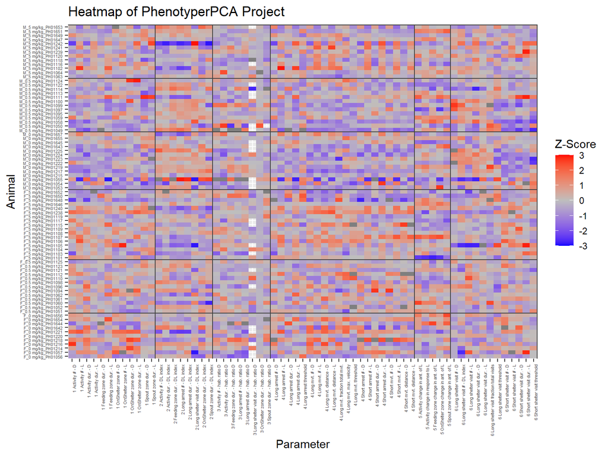

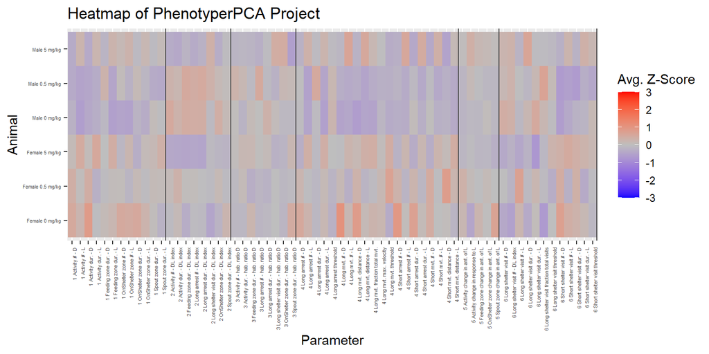

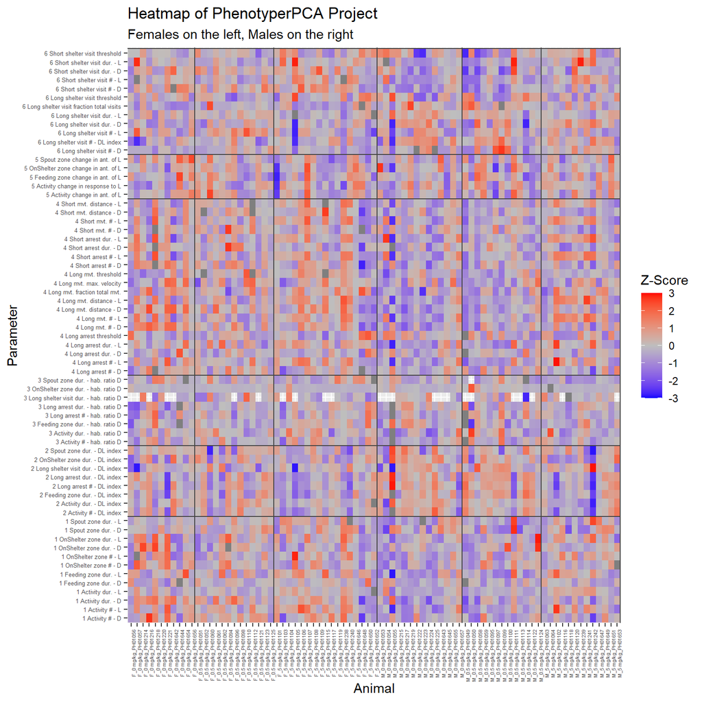

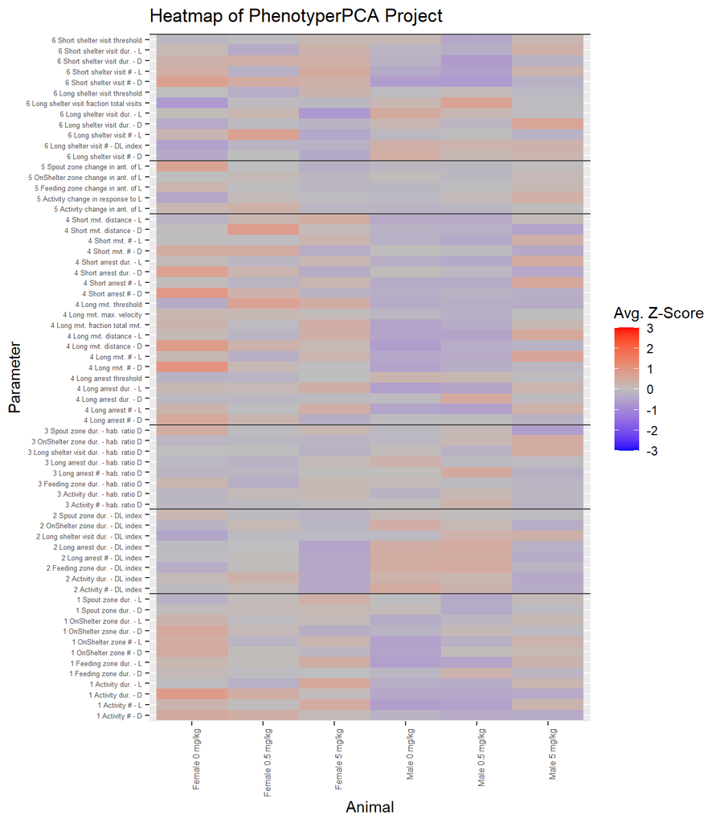

### Clustered Heatmap

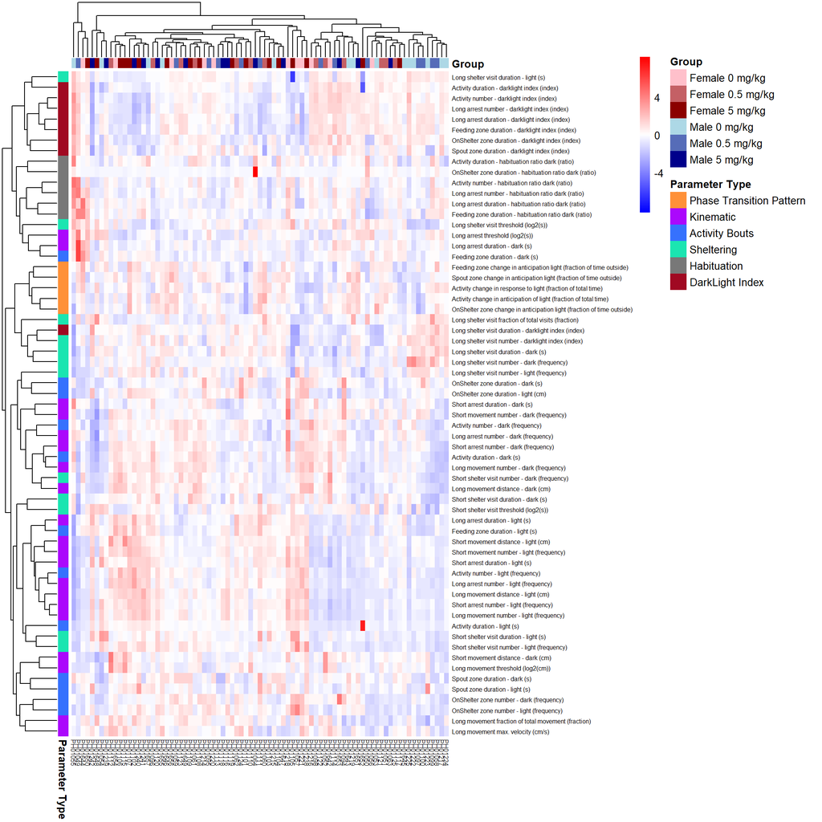

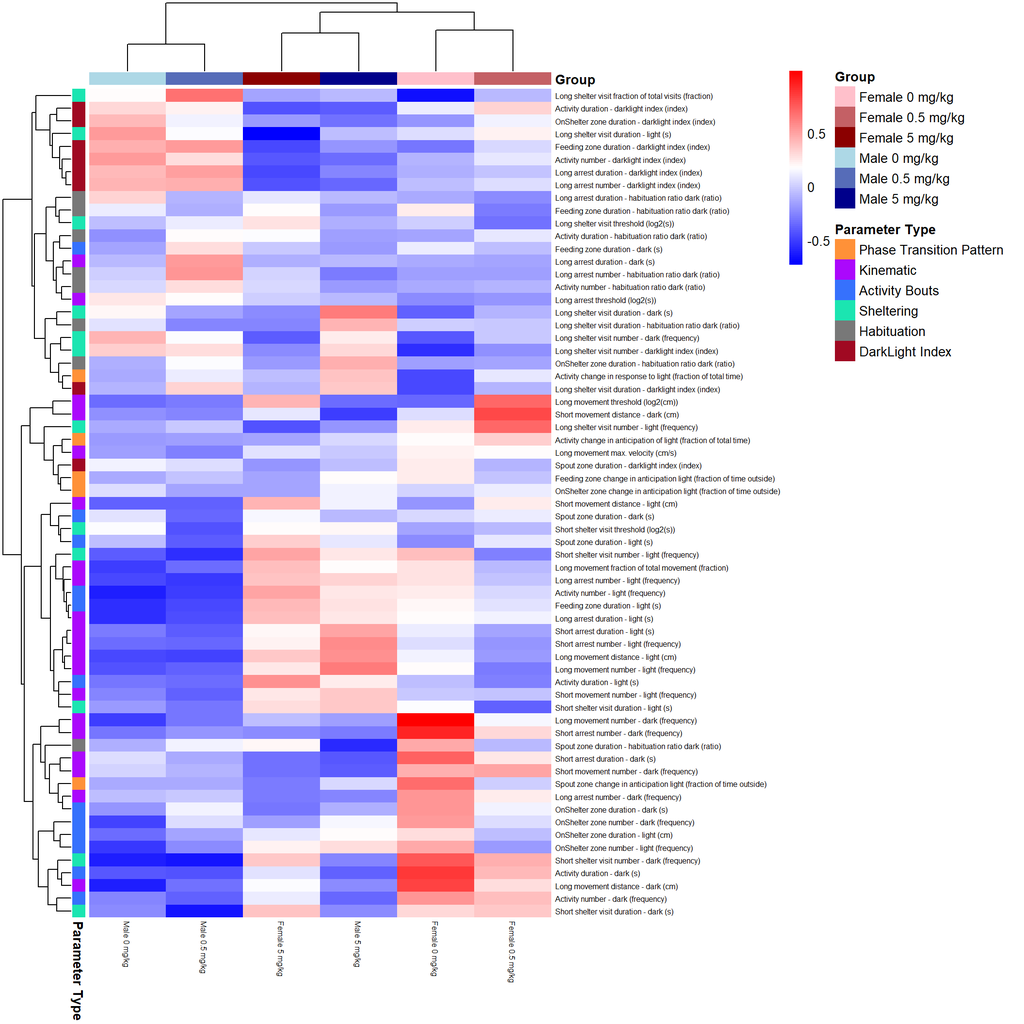

## ANOVA of main variables

A colored box indicates that the variable was significant at the 0.05 level.

The model results shown below are from a nested model - first interaction models are performed, and if the interaction is not significant, then additive models are performed.If Interaction p-value is significant (alpha < 0.05), then the main effect p-values are from that interaction model. If the Interaction p-value is not significant, the the main effect p-values are from an additive model.

### Graphical Results

The nested model structure can be visualized below. A significant interaction term from an interaction model is in its parameter type color (green, purple, etc.). The other terms in the interaction model (sex and Group) are grey if not significant and colorful if significant. A non-significant interaction model is replaced with an additive model. Additive models have a white interaction as a placeholder (there is no interaction in the additive model). Otherwise, the main terms are grey if not significant and colorful if significant.

Colorful - significant term Grey - non-significant term in the model White - term not in model (additive)

The two plots below show the same model output, but the first is filtered for those variables that had a significant Group term or a significant interaction term. The second plot shows all variables.

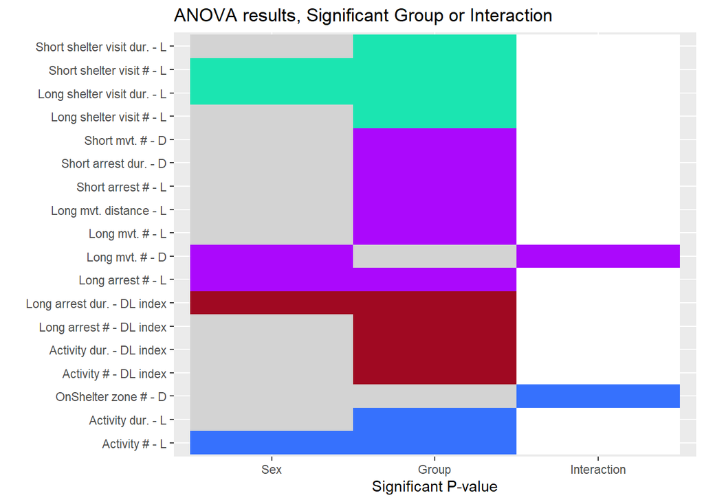

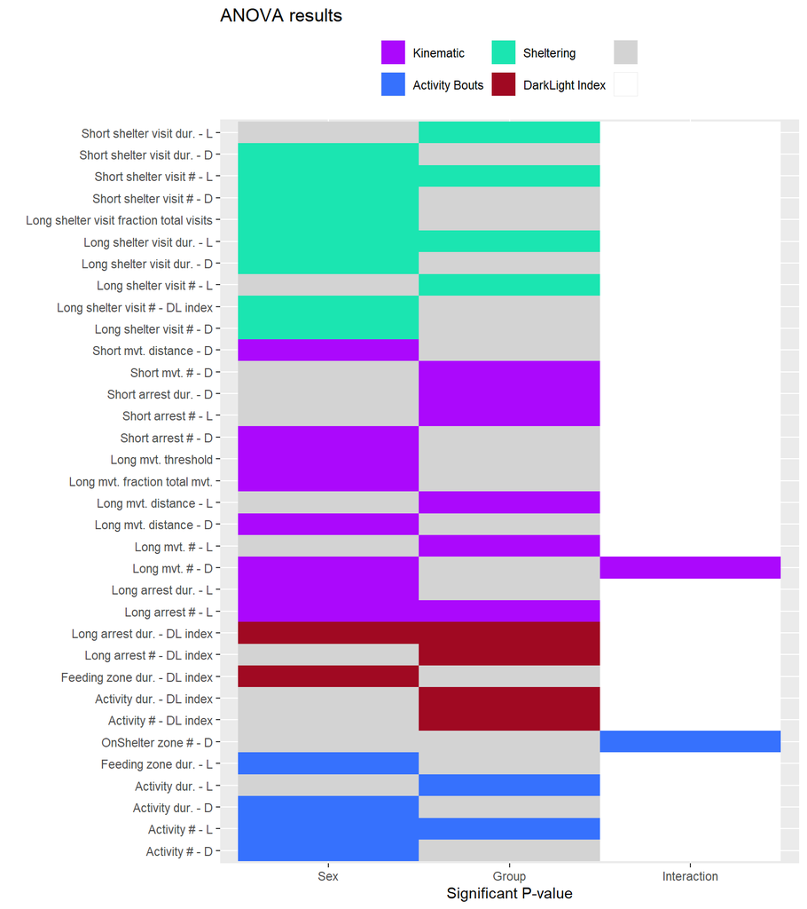

### Tabular Results

ANOVA results

[output not shown]

## Principal Components Analysis

Significant PCs, based off of an ANOVA.

PCs with a significant ANOVA covariate (nested model)

| PC | % Variation Explained | ANOVA p-values Sex | ANOVA p-values Group | ANOVA p-values Sex x Group |
| --- | --- | --- | --- | --- |
| PC1 | 25.3% | 0.02 | 0.03 | NA |
| PC2 | 15.2% | 0.00 | 0.12 | NA |
| PC13 | 1.7% | 0.04 | 0.31 | NA |
| PC17 | 1.1% | 0.69 | 0.65 | 0.00 |
| PC20 | 0.8% | 0.05 | 0.37 | NA |
| PC21 | 0.8% | 0.22 | 0.01 | NA |
| PC32 | 0.2% | 0.01 | 0.35 | NA |
| PC37 | 0.2% | 0.05 | 0.10 | 0.03 |
| PC38 | 0.1% | 0.04 | 0.76 | NA |
| PC42 | 0.1% | 0.23 | 0.34 | 0.01 |

Shaded rows indicate that the % of variation explained by the PC is greater than 1.5%, and their score and loading plots will be shown below.  
Bolded cells indicate a p-value less than 0.05.  
Nested model: If Interaction p-value is significant (alpha < 0.05), then the main effect p-values are from that interaction model. If the Interaction p-value is not significant, the the main effect p-values are from an additive model.

If the PC explains less than 1.5% of the variability, its Loadings and Scores are not plotted in the Significant PC Plots tab.

For completeness, all PCs are shown below.

PCs with a significant ANOVA covariate (nested model)

[output not shown]

Shaded rows indicate that the % of variation explained by the PC is greater than 1.5% with a significant model term, and their score and loading plots will be shown below.  
Bolded cells indicate a p-value less than 0.05.  
Nested model: If Interaction p-value is significant (alpha < 0.05), then the main effect p-values are from that interaction model. If the Interaction p-value is not significant, the the main effect p-values are from an additive model.

## Pairwise comparisons for Significant PCs

Tukey Pairwise Comparisons PCs with a significant ANOVA covariate (nested model)

| Label | PC1 | PC2 | PC13 |
| --- | --- | --- | --- |
| Percent_Var_Explained | 25.31% | 15.16% | 1.69% |
| 0 mg/kg: Male - Female | 0.031 * | 0.002 ** | 0.043 * |
| 0.5 mg/kg: Male - Female | 0.031 * | 0.002 ** | 0.043 * |
| 5 mg/kg: Male - Female | 0.031 * | 0.002 ** | 0.043 * |
| Male: (0 mg/kg) - (0.5 mg/kg) | 0.92 | 0.798 | 0.418 |
| Male: (0 mg/kg) - (5 mg/kg) | 0.114 | 0.115 | 0.997 |
| Male: (0.5 mg/kg) - (5 mg/kg) | 0.042 * | 0.358 | 0.344 |
| Female: (0 mg/kg) - (0.5 mg/kg) | 0.92 | 0.798 | 0.418 |
| Female: (0 mg/kg) - (5 mg/kg) | 0.114 | 0.115 | 0.997 |
| Female: (0.5 mg/kg) - (5 mg/kg) | 0.042 * | 0.358 | 0.344 |
| Effect | Additive | Additive | Additive |

Nested model: If Interaction p-value is significant (alpha < 0.05), then the main effect p-values are from that interaction model. If the Interaction p-value is not significant, the the main effect p-values are from an additive model.  
Pairwise Testing: Tukey pairwise tests are done for sex within Group levels and for Group within sex.  
**: p<0.01  
*: p<0.05

## Significant PC Plots

The main two outputs from PCA are Loadings and Scores, with one loading and one set of scores per PC. Loadings are the directions of biggest spread in the data, or can be thought of as a set of weights for the variables. Scores are then the weighted sum of each individual animal’s variable values.

Let’s say Animal A had values (a, b, c, …, x, y, z), where each value is a different variable.

Let’s say the Loadings for PC1 are (0.20, 0.15, 0.10, …, -0.05, -0.10, -0.20), where each value corresponds to a different variable.

The Score for Animal A on PC1 then is 0.20a + 0.15b + 0.10c + … - 0.05x - 0.10y - 0.20z

Hopefully this example will give context and understanding for the connection between the Loadings and Scores.

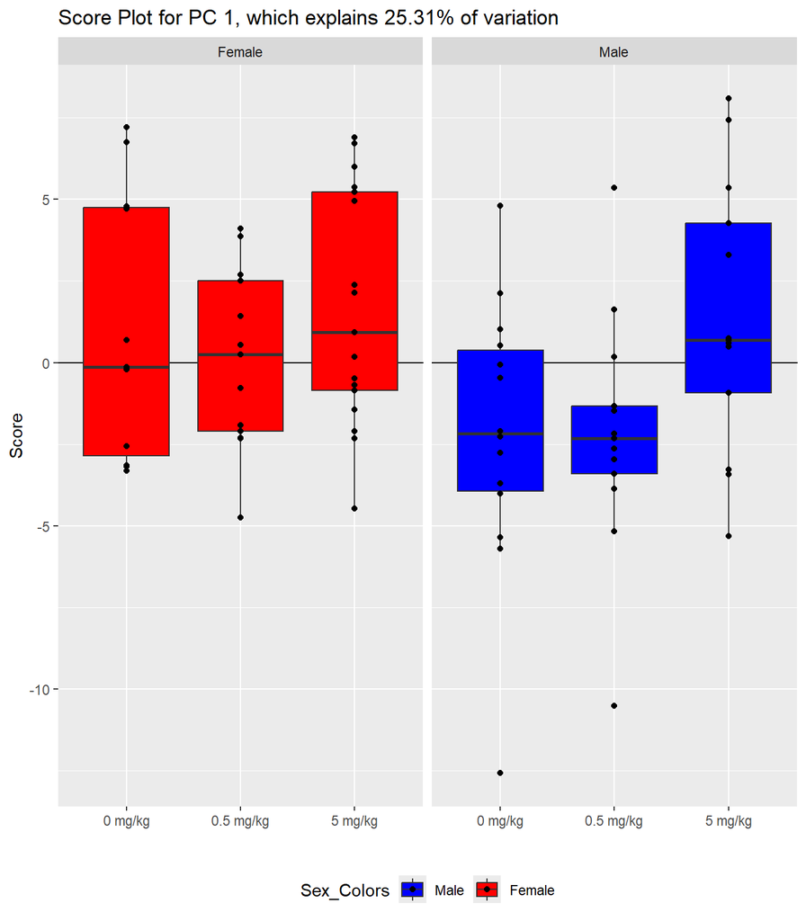

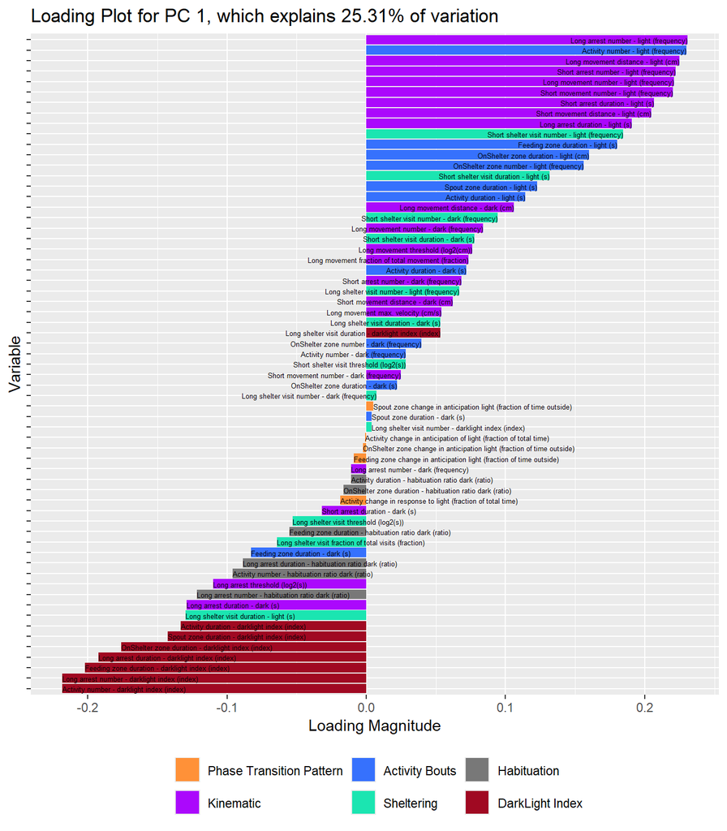

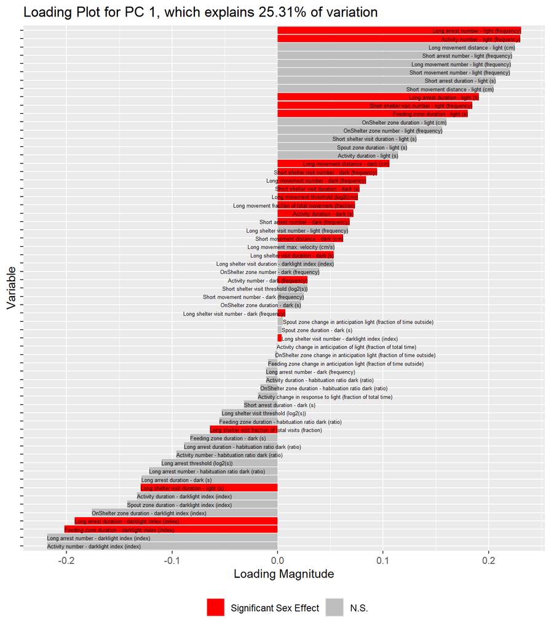

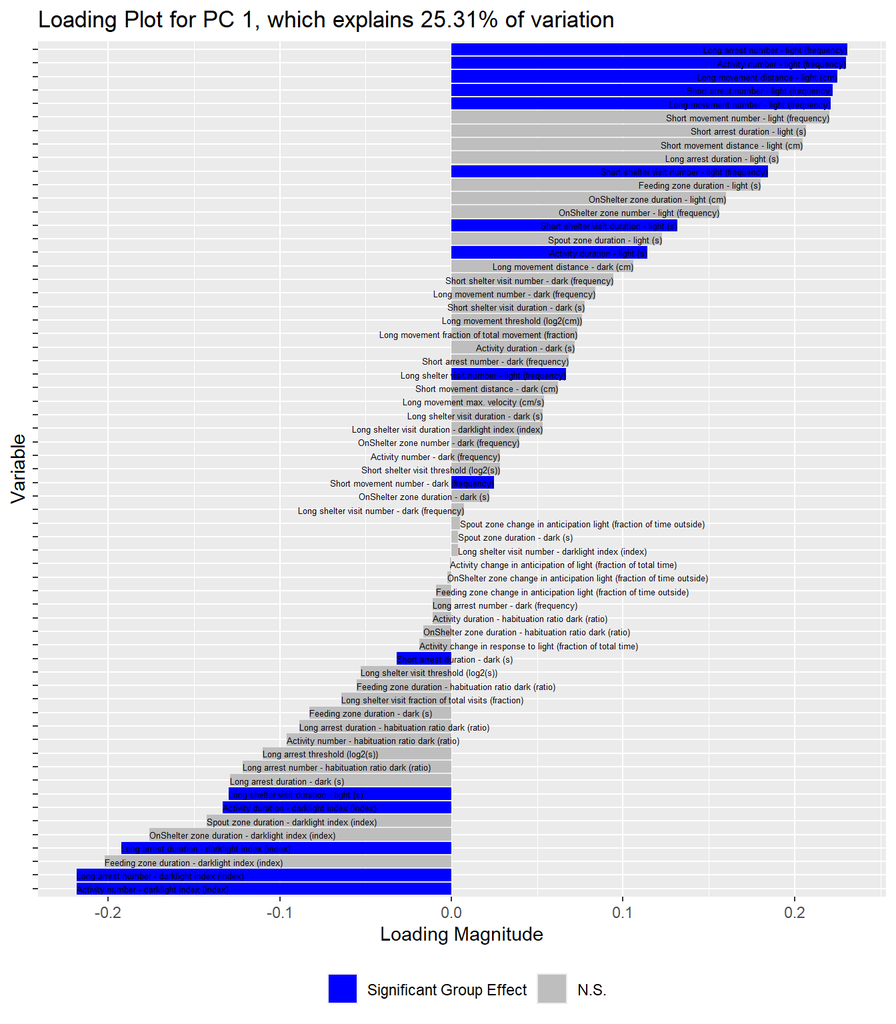

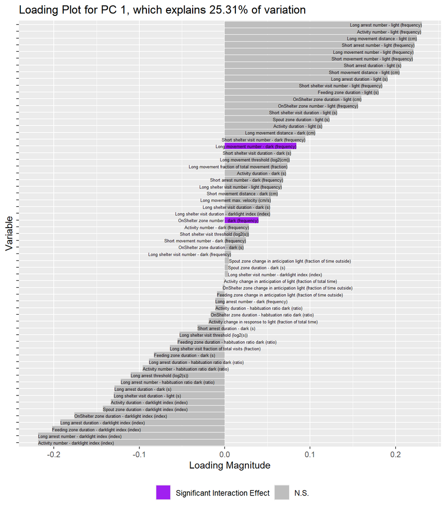

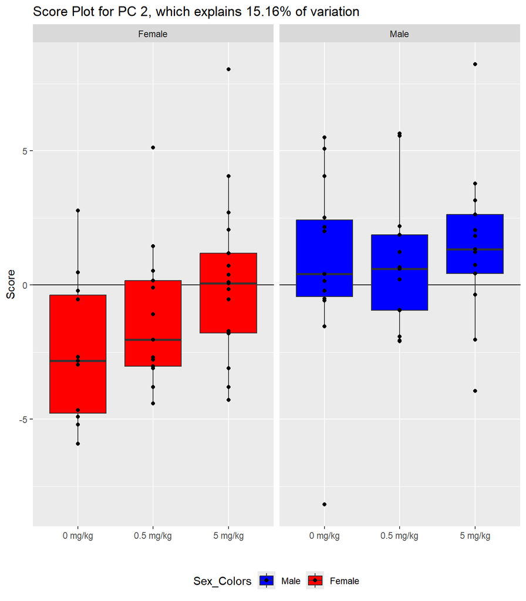

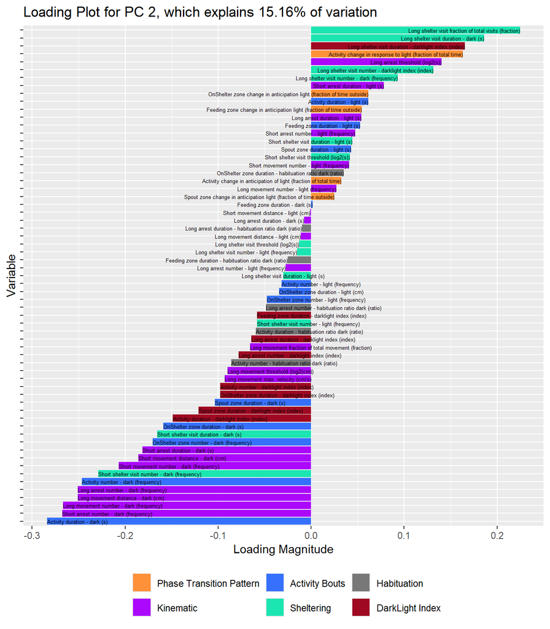

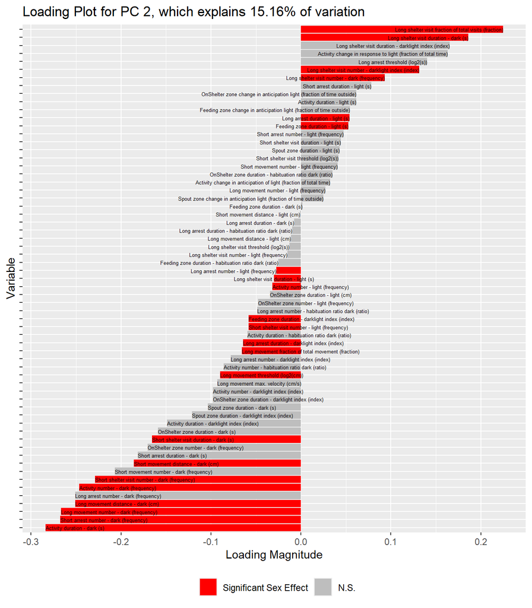

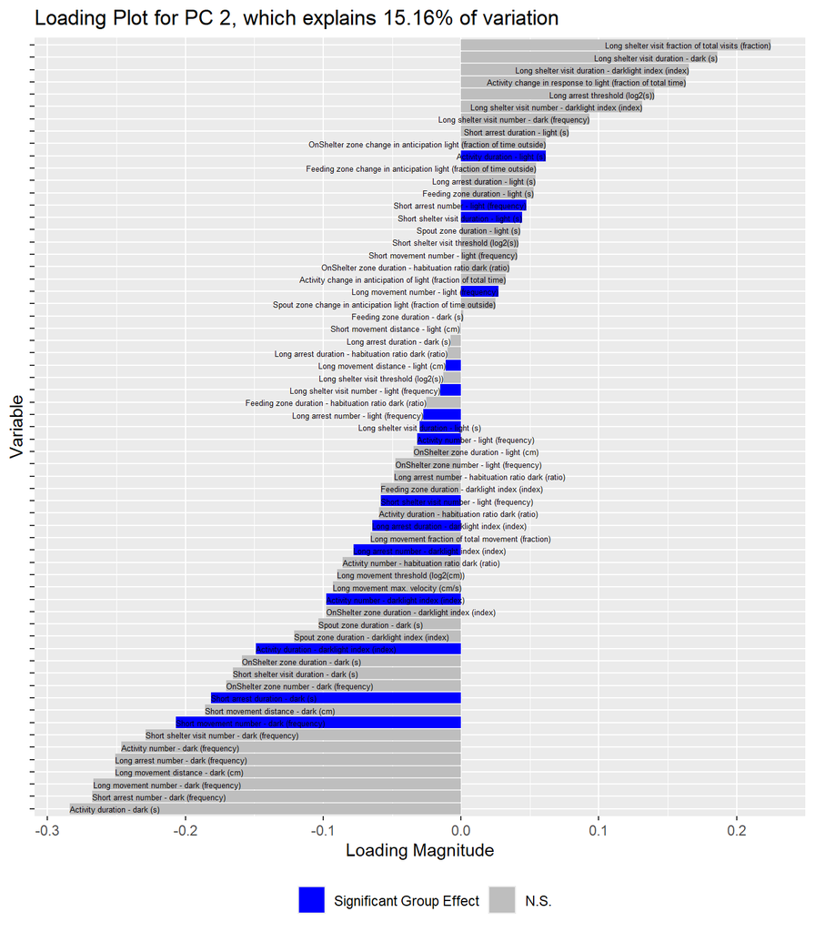

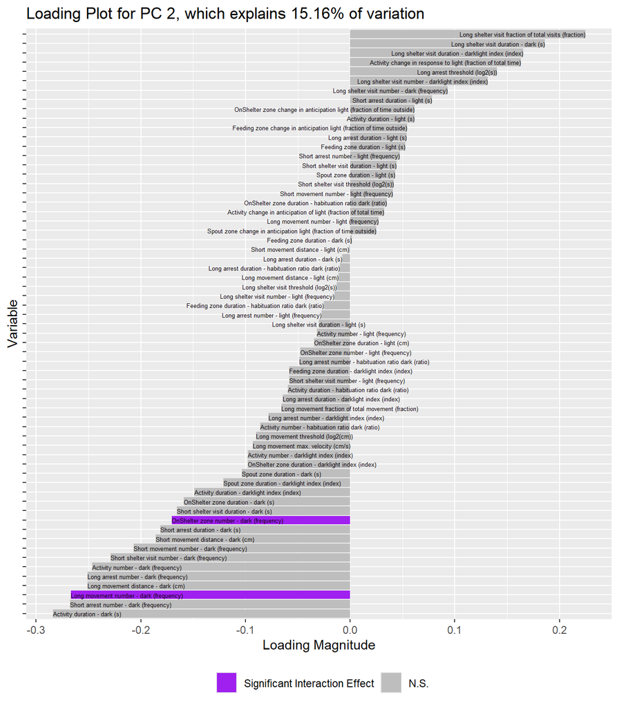

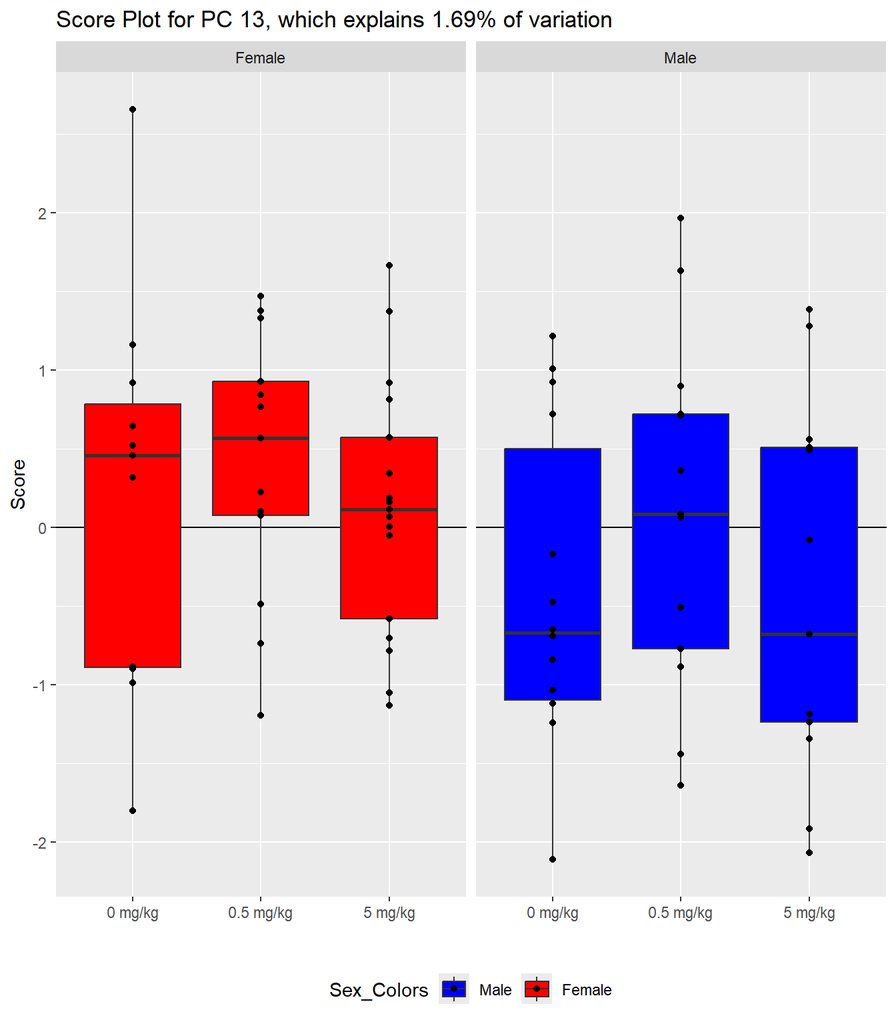

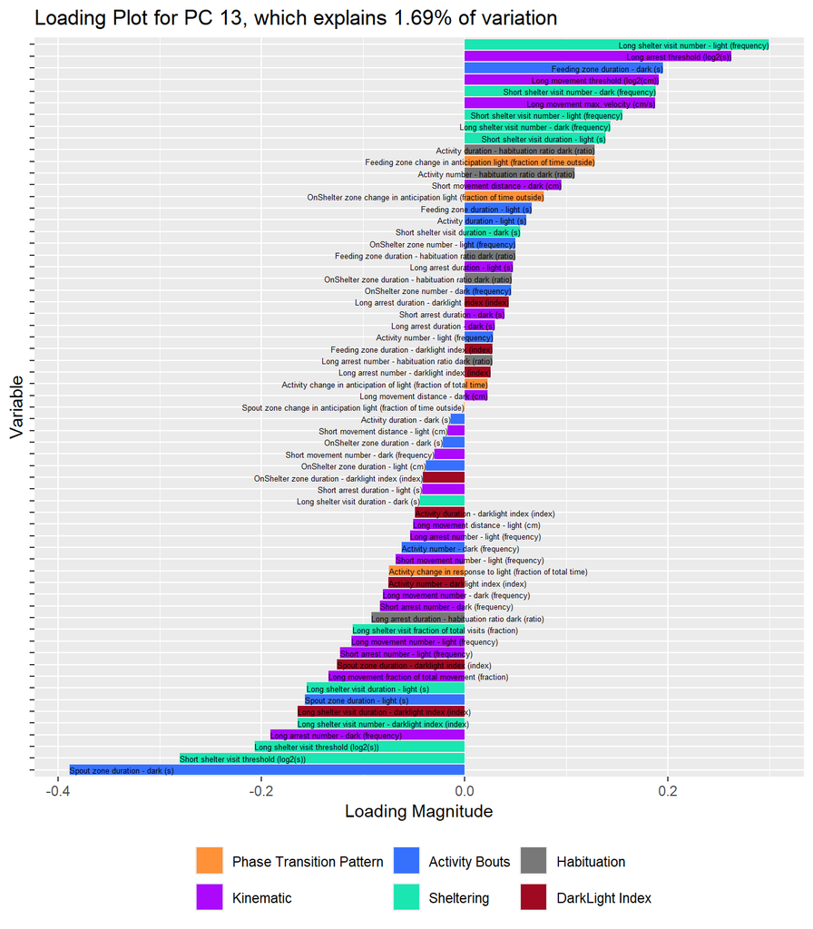

[3 more figures not shown]

## Other PC Plots

Below are plots of first three principal components. The first 3D plot is interactive; it can be clicked, dragged, and reoriented. The lower three plots show each of the first three PCs against the others.

[interactive chart not shown]

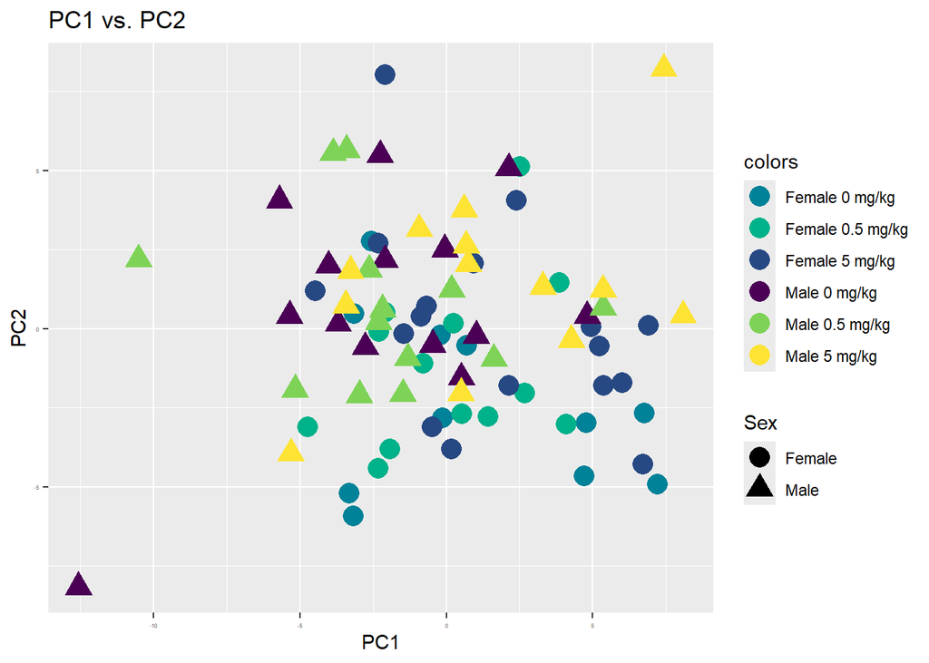

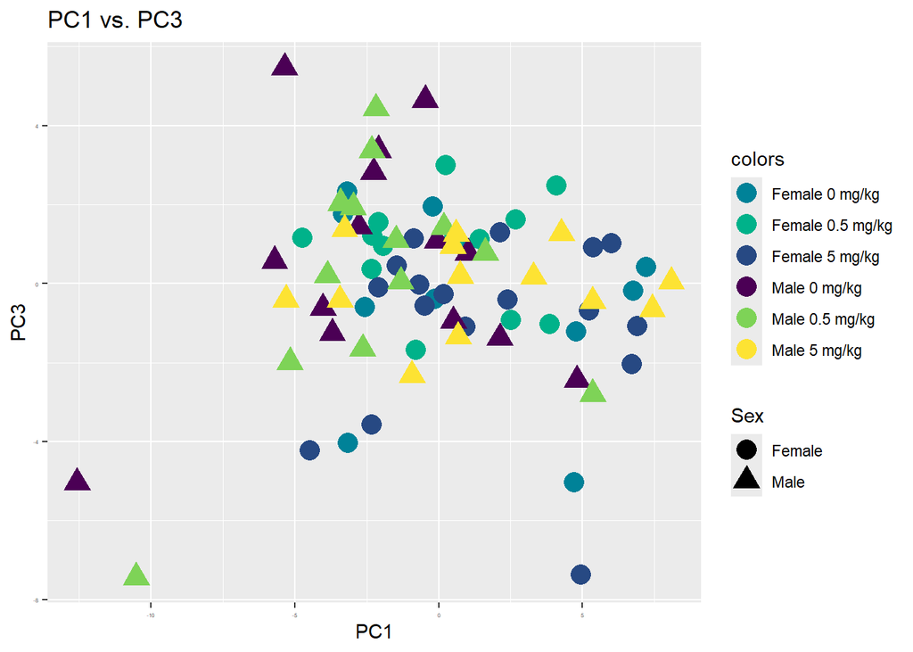

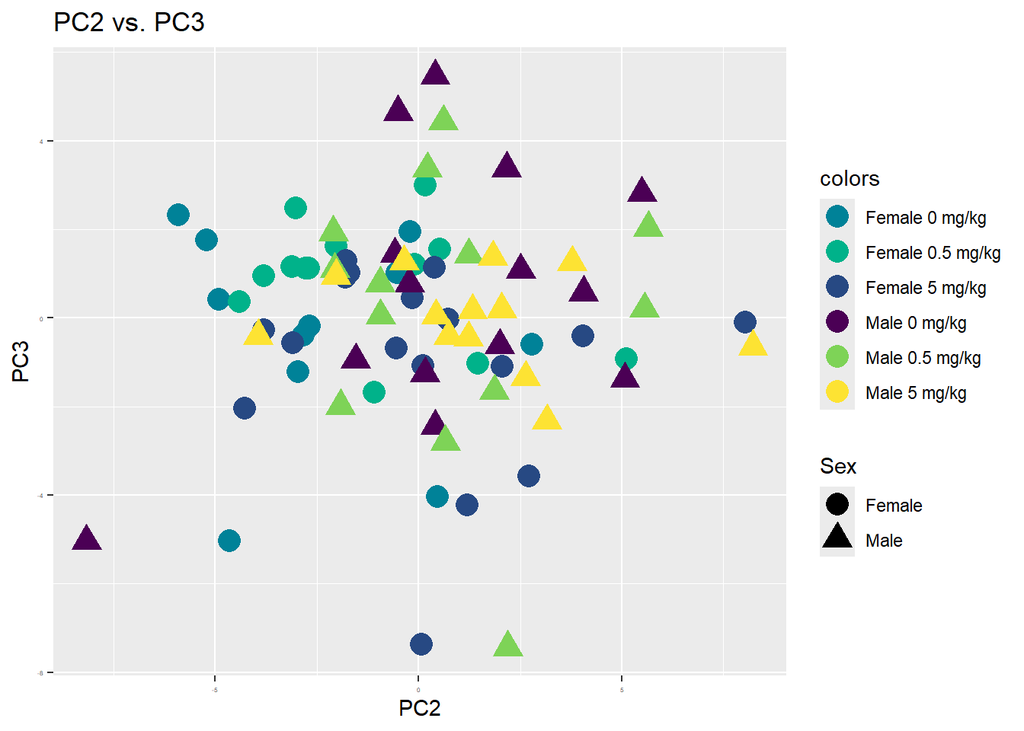

## Extra Statistical Details

For completeness, there are a few extra outputs that are useful for statistical QC, particularly when there are litter effects present in the data.

### % Variability explained by litter in raw data

If litter effects are present, the following is a table with the percent of variability explained by the random litter effect in an interaction model with Sex, Group, and their interaction. If the percent of variability is less than 1%, then the values are not adjusted for litter.

```
## [1] "Not applicable - no litter effects"
```

### Percent of variability explained by litter in ANOVA models on adjusted data

These ANOVAs were done after the adjustments. We do not expect there to be big litter effects present. Models are nested ANOVAs (interaction first, if not significant, then additive).

```
## [1] "Not applicable - no litter effects"
```

### Percent of Variability explained by litter in ANOVA models on PCs

These ANOVAs, run on the principal components, were done after the adjustments. We do not expect there to be big litter effects present. Models are nested ANOVAs (interaction first, if not significant, then additive).

```
## [1] "Not applicable - no litter effects"
```

# Output results

While many of the results have been presented in graphical or tabular form here, it may be useful to see them in table form. You can find them in ../Results for Practice/PhenotyperPCA Project_PCASuite_2026-06-25.xlsx.